##### Setup:

## Load Libraries

```r
# Load standard libraries
library(tidyverse)
library(gridExtra)
library(MASS)
library(pROC)
library(arm)
library(randomForest)
library(xgboost)
```

# Objective:

The objective of this project is to build a model to predict survival of passengers using the titanic dataset. The Titanic text file contains data about the survival of passengers aboard the Titanic.

```r
# Load data
titanic_data <- read.csv('titanic.csv')
#str(titanic_data) # explore data structure
titanic_data$pclass <- as.factor(titanic_data$pclass)
#str(titanic_data)
```

As part of this project I am trying to evaluate the performance of a few different statistical learning methods. Here, I am fitting fit a particular statistical learning method on a set of training observations and measure its performance on a set of test observations.

In this step I split the data into a training and test set based on an 80-20 split, in other words, 80% of the observations will be in the training set.

```r
#Take 80% of data out of the whole data set
smp_size <- floor(0.8 * nrow(titanic_data))

#Set a seed for ramdom sampling
set.seed(123)
#Create index of the data based on the sample size
train_ind <- sample(seq_len(nrow(titanic_data)), size = smp_size)

#Split the data into training and test data
train <- titanic_data[train_ind, ]
test <- titanic_data[-train_ind, ]
```

In this project set our goal is to predict the survival of passengers. First using Logistic Regression, let’s try to fit a model and find accuracy

```r
#Logistic regression on socioeconomic status
glm1 <- glm(survived~pclass+fare, data = train, family = "binomial")
summary(glm1)
```

```
##
## Call:
## glm(formula = survived ~ pclass + fare, family = "binomial",
##     data = train)
##
## Deviance Residuals:
##     Min       1Q   Median       3Q      Max
## -1.8672  -0.7938  -0.7486   1.0912   1.6989
##
## Coefficients:
##              Estimate Std. Error z value Pr(>|z|)
## (Intercept)  0.034998   0.196414   0.178  0.85858
## pclass2     -0.394787   0.212993  -1.854  0.06381 .
## pclass3     -1.208647   0.202274  -5.975  2.3e-09 ***
## fare         0.005764   0.002004   2.876  0.00403 **
## ---
## Signif. codes:  0 '***' 0.001 '**' 0.01 '*' 0.05 '.' 0.1 ' ' 1
##
## (Dispersion parameter for binomial family taken to be 1)
##
##     Null deviance: 1397.3  on 1045  degrees of freedom
## Residual deviance: 1277.8  on 1042  degrees of freedom
##   (1 observation deleted due to missingness)
## AIC: 1285.8
##
## Number of Fisher Scoring iterations: 4
```

```r
#Bayes logistic regression on socioeconomic status
bayesglm1 <- bayesglm(survived~pclass+fare, data = train, family = "binomial")
summary(bayesglm1)
```

```
##
## Call:
## bayesglm(formula = survived ~ pclass + fare, family = "binomial",
##     data = train)
##
## Deviance Residuals:
##     Min       1Q   Median       3Q      Max
## -1.8726  -0.7954  -0.7494   1.0959   1.6981
##
## Coefficients:
##              Estimate Std. Error z value Pr(>|z|)
## (Intercept)  0.020550   0.195006   0.105  0.91607
## pclass2     -0.380367   0.211027  -1.802  0.07147 .
## pclass3     -1.192517   0.200603  -5.945 2.77e-09 ***
## fare         0.005865   0.002004   2.927  0.00342 **
## ---
## Signif. codes:  0 '***' 0.001 '**' 0.01 '*' 0.05 '.' 0.1 ' ' 1
##
## (Dispersion parameter for binomial family taken to be 1)
##
##     Null deviance: 1397.3  on 1045  degrees of freedom
## Residual deviance: 1277.8  on 1042  degrees of freedom
##   (1 observation deleted due to missingness)
## AIC: 1285.8
##
## Number of Fisher Scoring iterations: 4
```

## Observations using Logistic Regression

After carefully observing both the models that is logistic regression and bayes logistic regression, it can be seen that the p-value for pclass3 and fare is much less than 0.05. Hence, the response variable is significantly associated with pclass 3 and fare.

Next, let’s consider the performance of this model.

Predict each observation from test data set using the above model and save the predictions in yhat. Use a threshold of 0.5 to classify predictions.

```r
#Find probability of survival for each passenger
yhat <- predict.glm(glm1, newdata = test, type = "response")

#Convert the probability to 0 or 1
yhat <- ifelse(yhat > 0.5,1,0)

#Create confusion matrix
table(yhat, test$survived)
```

```
##
## yhat   0   1
##    0 145  62
##    1  23  32
```

```r
#Accuracy of the predictio model
(145+32)/262
```

```
## [1] 0.6755725
```

# Observation

The accuracy of the model is around 67.55%. This indicates a moderate performance of our model.

Let’s plot the roc curve for this model

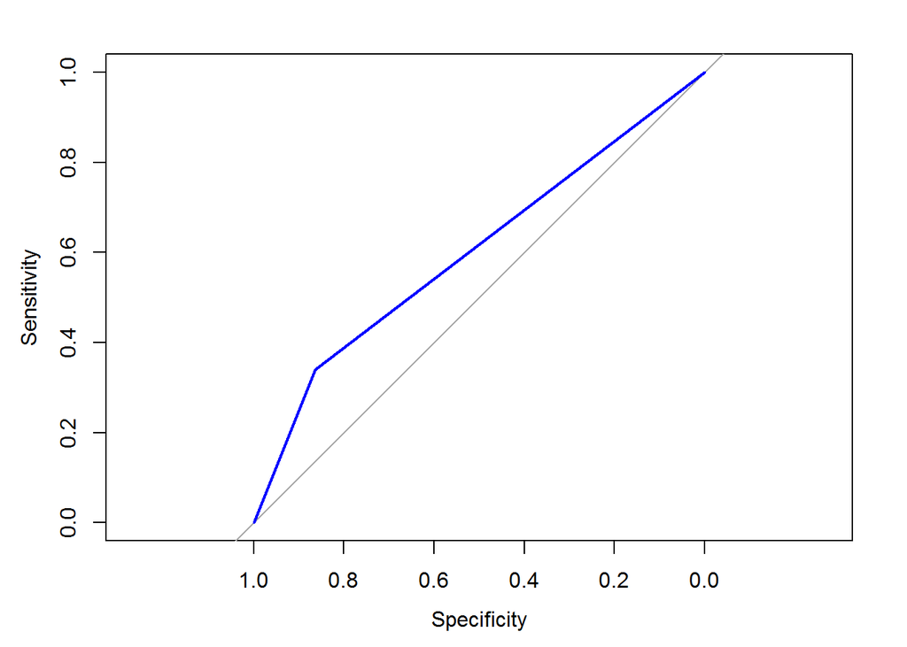

```
##
## Call:
## roc.default(response = test$survived, predictor = yhat)
##
## Data: yhat in 168 controls (test$survived 0) < 94 cases (test$survived 1).
## Area under the curve: 0.6018
```

```r
#Plot ROC curve
plot(roc(test$survived,yhat), col= "blue")
```

Let’s try to improve the performace by addingnew feature to the dataset. I added the prefix for every passeneger (Mr.,Miss, Col,..). First seperated the prefix from the name variable and added itto another column. Then, categorized the the dataset into factors based on the prefix.

```r
#Convert name to char
titanic_data$name <- as.character(titanic_data$name)

#Split title from name which is  between comma and period
titanic_data$title <- sapply(titanic_data$name,
               FUN=function(x) {strsplit(x, split='[,.]')[[1]][2]})

#Remove an extra space from the title variable
titanic_data$title <- sub(' ', '', titanic_data$title)

#Group by title to find unique titles present
titanic_temp <- titanic_data %>%
  group_by(title) %>%
  summarise(n())

#Create groups of title to account for single entries of data
titanic_data$title[titanic_data$title %in% c('Mme', 'Mlle', 'Ms')] <- 'Miss'
titanic_data$title[titanic_data$title %in%
                     c('Capt', 'Col', 'Don','Dr', 'Major', 'Sir', 'Rev')] <- 'Sir'
titanic_data$title[titanic_data$title %in%
                     c('Dona', 'Jonkheer', 'Lady', 'the Countess')] <- 'Lady'

#Convert title to factor
titanic_data$title <- as.factor(titanic_data$title)
```

Again apply logistic regression to test whether the addition of new variable has improved the model performance.

```r
#Create training and test data set for the new data set after adding title variable
smp_size <- floor(0.8 * nrow(titanic_data))

set.seed(123)
train_index <- sample(seq_len(nrow(titanic_data)), size = smp_size)

train1 <- titanic_data[train_index, ]
test1 <- titanic_data[-train_index, ]

#Fit bayes logistic regression model on the training data
bayesglm2<- bayesglm(survived~pclass+fare+title, data = train1,
                     family = "binomial")
summary(bayesglm2)
```

```
##
## Call:
## bayesglm(formula = survived ~ pclass + fare + title, family = "binomial",
##     data = train1)
##
## Deviance Residuals:
##     Min       1Q   Median       3Q      Max
## -2.2326  -0.6218  -0.3837   0.6627   2.3005
##
## Coefficients:
##               Estimate Std. Error z value Pr(>|z|)
## (Intercept)  1.181e+00  7.447e-01   1.586   0.1128
## pclass2     -9.869e-01  2.525e-01  -3.909 9.28e-05 ***
## pclass3     -2.013e+00  2.463e-01  -8.171 3.05e-16 ***
## fare         7.405e-05  1.889e-03   0.039   0.9687
## titleMaster  5.492e-01  7.750e-01   0.709   0.4785
## titleMiss    1.152e+00  7.453e-01   1.546   0.1221
## titleMr     -1.741e+00  7.349e-01  -2.369   0.0178 *
## titleMrs     1.209e+00  7.514e-01   1.609   0.1077
## titleSir    -1.374e+00  8.352e-01  -1.646   0.0998 .
## ---
## Signif. codes:  0 '***' 0.001 '**' 0.01 '*' 0.05 '.' 0.1 ' ' 1
##
## (Dispersion parameter for binomial family taken to be 1)
##
##     Null deviance: 1397.27  on 1045  degrees of freedom
## Residual deviance:  937.73  on 1037  degrees of freedom
##   (1 observation deleted due to missingness)
## AIC: 955.73
##
## Number of Fisher Scoring iterations: 7
```

## Observations:

```r
#Predict the probabilities of survival for the new model
yhat2 <- predict.glm(bayesglm2, newdata = test1, type = "response")

#Convert the values to 0 and 1 based on threshold
yhat2 <- ifelse(yhat2 > 0.5,1,0)
#Create confusion matrix
table(yhat2, test1$survived)
```

```
##
## yhat2   0   1
##     0 138  33
##     1  30  61
```

```r
#Accruacy
(138+61)/262
```

```
## [1] 0.759542
```

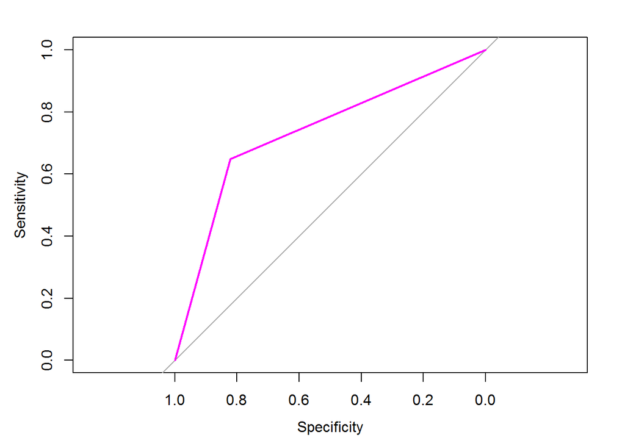

```
##
## Call:
## roc.default(response = test1$survived, predictor = yhat2)
##
## Data: yhat2 in 168 controls (test1$survived 0) < 94 cases (test1$survived 1).
## Area under the curve: 0.7352
```

```r
#Plot ROC curve including title variable
plot(roc(test1$survived,yhat2), col="magenta")
```

## Observations:

The accuracy of the new model is 75.95%. The accuracy has increased as compared to the previos model after adding title variable. The area under the curve on adding the title variable is 73% which is more than the ROC curve plotted for the previous model.

Let’s try to fit randomForest classifier to see whether the performance of the model in predicting new observations increases or not.

Fit a model using randomForest and predict the values from test dataset. Store them as yhat3.

```r
#Fit randomForest model
set.seed(1)
rm1 <- randomForest(survived~pclass+title, data = train1, ntree = 500,
                    importance= T)
summary(rm1)
```

```
##                 Length Class  Mode
## call               5   -none- call
## type               1   -none- character
## predicted       1047   -none- numeric
## mse              500   -none- numeric
## rsq              500   -none- numeric
## oob.times       1047   -none- numeric
## importance         4   -none- numeric
## importanceSD       2   -none- numeric
## localImportance    0   -none- NULL
## proximity          0   -none- NULL
## ntree              1   -none- numeric
## mtry               1   -none- numeric
## forest            11   -none- list
## coefs              0   -none- NULL
## y               1047   -none- numeric
## test               0   -none- NULL
## inbag              0   -none- NULL
## terms              3   terms  call
```

```r
#Predict values for test data
yhat3 <- predict(rm1, test1, type="response")
```

Add new predictor variables to improve the performace of the model .

```r
#Fit randomForest model adding a new variable
set.seed(111)
rm2 <- randomForest(survived~pclass+title+sex, data = train1, ntree = 500,
                    importance= T)
summary(rm2)
```

```
##                 Length Class  Mode
## call               5   -none- call
## type               1   -none- character
## predicted       1047   -none- numeric
## mse              500   -none- numeric
## rsq              500   -none- numeric
## oob.times       1047   -none- numeric
## importance         6   -none- numeric
## importanceSD       3   -none- numeric
## localImportance    0   -none- NULL
## proximity          0   -none- NULL
## ntree              1   -none- numeric
## mtry               1   -none- numeric
## forest            11   -none- list
## coefs              0   -none- NULL
## y               1047   -none- numeric
## test               0   -none- NULL
## inbag              0   -none- NULL
## terms              3   terms  call
```

```r
#Predict values
yhat4 <- predict(rm2, test1, type="response")
```

```r
plot(roc(test1$survived,yhat3), col= "red")
```

```
##
## Call:
## roc.default(response = test1$survived, predictor = yhat3)
##
## Data: yhat3 in 168 controls (test1$survived 0) < 94 cases (test1$survived 1).
## Area under the curve: 0.7851
```

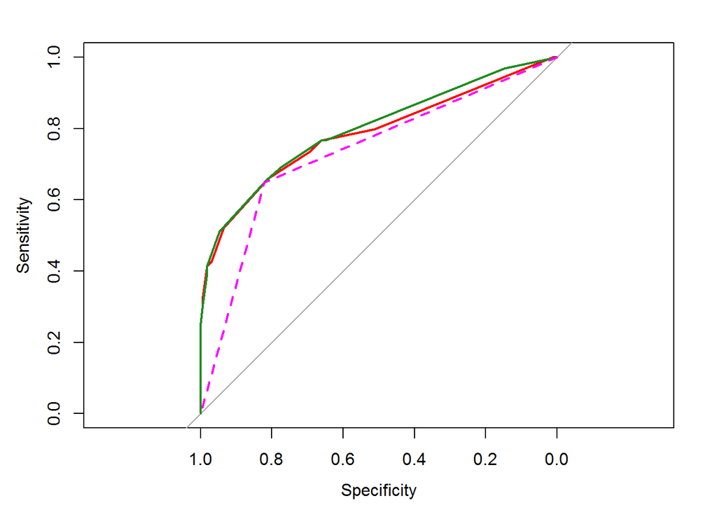

```r
lines(roc(test1$survived,yhat4), col= "forestgreen", lty=1)
lines(roc(test1$survived,yhat2), col="magenta", lty=2)
```

# Observations